# **Data ingestion & inspection**

## Plotting DataFrames

```python
weather = pd.read_csv(match[-3])
weather.head()
```

|  | Temperature | DewPoint | Pressure | Date |
| --- | --- | --- | --- | --- |
| 0 | 46.2 | 37.5 | 1.0 | 20100101 00:00 |
| 1 | 44.6 | 37.1 | 1.0 | 20100101 01:00 |
| 2 | 44.1 | 36.9 | 1.0 | 20100101 02:00 |
| 3 | 43.8 | 36.9 | 1.0 | 20100101 03:00 |
| 4 | 43.5 | 36.8 | 1.0 | 20100101 04:00 |

```python
weather.info()
```

```
<class 'pandas.core.frame.DataFrame'>
RangeIndex: 8759 entries, 0 to 8758
Data columns (total 4 columns):
Temperature    8759 non-null float64
DewPoint       8759 non-null float64
Pressure       8759 non-null float64
Date           8759 non-null object
dtypes: float64(3), object(1)
memory usage: 273.8+ KB
```

```python
weather.columns
```

```
Index(['Temperature', 'DewPoint', 'Pressure', 'Date'], dtype='object')
```

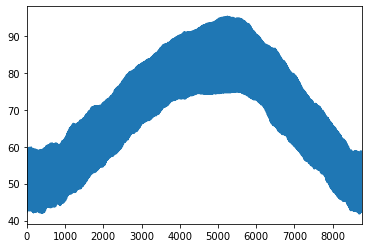

```python
weather.Temperature.plot()
plt.show()
```

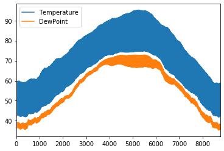

```python
column_list = ['Temperature', 'DewPoint']
weather[column_list].plot(subplots = False)
```

[output not shown]

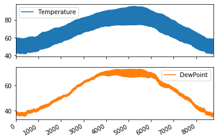

```python
weather[column_list].plot(subplots = True)
```

[output not shown]

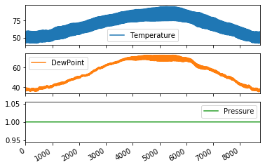

```python
weather.plot(subplots=True)
```

# **Exploratory data analysis**

**Разведочный анализ данных** (*exploratory data analysis* (EDA)) — анализ основных свойств данных, нахождение в них общих закономерностей, распределений и аномалий, построение начальных моделей, зачастую с использованием инструментов визуализации.

## Visual exploratory data analysis

```python
iris_names = ['sepal_length', 'sepal_width', 'petal_length', 'petal_width', 'species']
iris = pd.read_csv('iris.csv', header = None, names = iris_names)
display(iris.shape)
display(iris.head())
```

```
(150, 5)
```

|  | sepal_length | sepal_width | petal_length | petal_width | species |
| --- | --- | --- | --- | --- | --- |
| 0 | 5.1 | 3.5 | 1.4 | 0.2 | Iris-setosa |
| 1 | 4.9 | 3.0 | 1.4 | 0.2 | Iris-setosa |
| 2 | 4.7 | 3.2 | 1.3 | 0.2 | Iris-setosa |
| 3 | 4.6 | 3.1 | 1.5 | 0.2 | Iris-setosa |
| 4 | 5.0 | 3.6 | 1.4 | 0.2 | Iris-setosa |

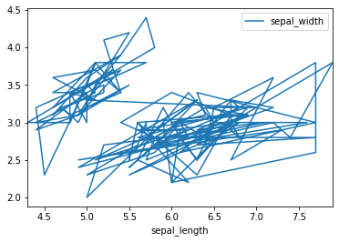

```python
iris.plot(x='sepal_length', y='sepal_width')
plt.show()
```

### Scatter plot

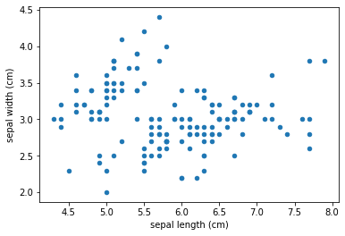

```python
iris.plot(x='sepal_length', y='sepal_width', kind='scatter')
plt.xlabel('sepal length (cm)')
plt.ylabel('sepal width (cm)')
plt.show()
```

### Box plot

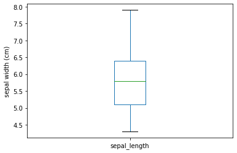

```python
iris.plot(y='sepal_length', kind='box')
plt.ylabel('sepal width (cm)')
plt.show()
```

### Histogram

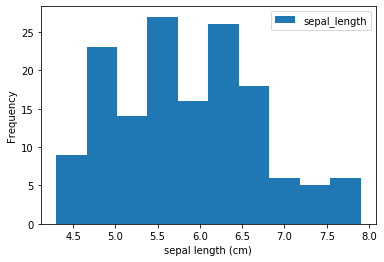

```python
iris.plot(y='sepal_length', kind='hist')
plt.xlabel('sepal length (cm)')
plt.show()
```

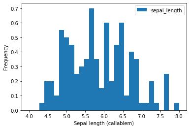

```python
iris.plot(y='sepal_length', kind='hist', bins=30, range=(4,8), density=True)
plt.xlabel('Sepal length (callablem)')
plt.show()
```

### Cumulative distribution function (CDF)

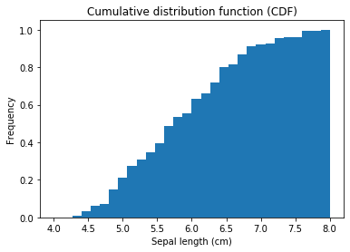

```python
iris.plot(y='sepal_length', kind='hist', bins=30, range=(4,8), density=True, cumulative=True, legend=False)
plt.xlabel('Sepal length (cm)')
plt.title('Cumulative distribution function (CDF)')
plt.show()
```

**Three different DataFrame plot idioms**

- iris.plot(kind='hist')
- iris.plt.hist()
- iris.hist()

```python
df['CountryCode'].unique()
```

```
array(['ARB', 'CSS', 'CEB', 'EAS', 'EAP', 'EMU', 'ECS', 'ECA', 'EUU',
       'FCS', 'HPC', 'HIC', 'NOC', 'OEC', 'LCN', 'LAC', 'LDC', 'LMY',
       'LIC', 'LMC', 'MEA', 'MNA', 'MIC', 'NAC', 'OED', 'OSS', 'PSS',
       'SST', 'SAS', 'SSF', 'SSA', 'UMC', 'WLD', 'AFG', 'ALB', 'DZA',
       'ASM', 'ADO', 'AGO', 'ATG', 'ARG', 'ARM', 'ABW', 'AUS', 'AUT',
       'AZE', 'BHS', 'BHR', 'BGD', 'BRB', 'BLR', 'BEL', 'BLZ', 'BEN',
       'BMU', 'BTN', 'BOL', 'BIH', 'BWA', 'BRA', 'BRN', 'BGR', 'BFA',
       'BDI', 'CPV', 'KHM', 'CMR', 'CAN', 'CYM', 'CAF', 'TCD', 'CHI',
       'CHL', 'CHN', 'COL', 'COM', 'ZAR', 'COG', 'CRI', 'CIV', 'HRV',
       'CUB', 'CUW', 'CYP', 'CZE', 'DNK', 'DJI', 'DMA', 'DOM', 'ECU',
       'EGY', 'SLV', 'GNQ', 'ERI', 'EST', 'ETH', 'FRO', 'FJI', 'FIN',
       'FRA', 'PYF', 'GAB', 'GMB', 'GEO', 'DEU', 'GHA', 'GRC', 'GRL',
       'GRD', 'GUM', 'GTM', 'GIN', 'GNB', 'GUY', 'HTI', 'HND', 'HKG',
       'HUN', 'ISL', 'IND', 'IDN', 'IRN', 'IRQ', 'IRL', 'IMY', 'ISR',
       'ITA', 'JAM', 'JPN', 'JOR', 'KAZ', 'KEN', 'KIR', 'PRK', 'KOR',
       'KWT', 'KGZ', 'LAO', 'LVA', 'LBN', 'LSO', 'LBR', 'LBY', 'LIE',
       'LTU', 'LUX', 'MAC', 'MKD', 'MDG', 'MWI', 'MYS', 'MDV', 'MLI',
       'MLT', 'MHL', 'MRT', 'MUS', 'MEX', 'FSM', 'MDA', 'MCO', 'MNG',
       'MNE', 'MAR', 'MOZ', 'MMR', 'NAM', 'NPL', 'NLD', 'NCL', 'NZL',
       'NIC', 'NER', 'NGA', 'MNP', 'NOR', 'OMN', 'PAK', 'PLW', 'PAN',
       'PNG', 'PRY', 'PER', 'PHL', 'POL', 'PRT', 'PRI', 'QAT', 'ROM',
       'RUS', 'RWA', 'WSM', 'SMR', 'STP', 'SAU', 'SEN', 'SYC', 'SLE',
       'SGP', 'SVK', 'SVN', 'SLB', 'SOM', 'ZAF', 'SSD', 'ESP', 'LKA',
       'KNA', 'LCA', 'VCT', 'SDN', 'SUR', 'SWZ', 'SWE', 'CHE', 'SYR',
       'TJK', 'TZA', 'THA', 'TMP', 'TGO', 'TON', 'TTO', 'TUN', 'TUR',
       'TKM', 'TCA', 'TUV', 'UGA', 'UKR', 'ARE', 'GBR', 'USA', 'URY',
       'UZB', 'VUT', 'VEN', 'VNM', 'VIR', 'YEM', 'ZMB', 'ZWE', 'SRB',
       'WBG', 'SXM'], dtype=object)
```

```python
# Filtering by species
df['CountryCode'].unique().shape
uzb = df['CountryCode'] == 'UZB'
rus = df['CountryCode'] == 'RUS'
nor = df['CountryCode'] =='NOR'
swe = df['CountryCode'] =='SWE'
den = df['CountryCode'] =='DNK'
can = df['CountryCode'] =='CAN'
pol = df['CountryCode'] == 'POL'
aus = df['CountryCode'] == 'AUS'
nzl = df['CountryCode'] == 'NZL'
aut = df['CountryCode'] == 'AUT'
ger = df['CountryCode'] == 'DEU'
fin = df['CountryCode'] == 'FIN'
swt = df['CountryCode'] == 'CHE'
bel = df['CountryCode'] == 'BEL'
uzbekistan = df.loc[uzb, :]
russia = df.loc[rus, :]
norway = df.loc[nor, :]
sweden = df.loc[swe, :]
denmark =df.loc[den, :]
canada = df.loc[can, :]
poland = df.loc[pol, :]
australia = df.loc[aus, :]
new_zealand = df.loc[nzl, :]
austria = df.loc[aut, :]
germany = df.loc[ger, :]
finland = df.loc[fin, :]
switzerland = df.loc[swt, :]
belgium = df.loc[bel, :]
display(uzbekistan.head())
display(russia.head())
```

|  | CountryName | CountryCode | Year | Total Population | Urban population (% of total) |
| --- | --- | --- | --- | --- | --- |
| 234 | Uzbekistan | UZB | 1960 | 8789492.0 | 33.978 |
| 476 | Uzbekistan | UZB | 1961 | 9044671.0 | 34.238 |
| 718 | Uzbekistan | UZB | 1962 | 9319510.0 | 34.500 |
| 960 | Uzbekistan | UZB | 1963 | 9611601.0 | 34.762 |
| 1202 | Uzbekistan | UZB | 1964 | 9917202.0 | 35.025 |

|  | CountryName | CountryCode | Year | Total Population | Urban population (% of total) |
| --- | --- | --- | --- | --- | --- |
| 189 | Russian Federation | RUS | 1960 | 119897000.0 | 53.731 |
| 431 | Russian Federation | RUS | 1961 | 121236000.0 | 54.626 |
| 673 | Russian Federation | RUS | 1962 | 122591000.0 | 55.518 |
| 915 | Russian Federation | RUS | 1963 | 123960000.0 | 56.408 |
| 1157 | Russian Federation | RUS | 1964 | 125345000.0 | 57.294 |

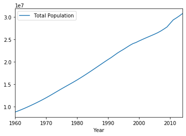

```python
uzbekistan.plot(y = 'Total Population', x = 'Year')
```

```python
russia.loc[rus,:].head()
```

|  | CountryName | CountryCode | Year | Total Population | Urban population (% of total) |
| --- | --- | --- | --- | --- | --- |
| 189 | Russian Federation | RUS | 1960 | 119897000.0 | 53.731 |
| 431 | Russian Federation | RUS | 1961 | 121236000.0 | 54.626 |
| 673 | Russian Federation | RUS | 1962 | 122591000.0 | 55.518 |
| 915 | Russian Federation | RUS | 1963 | 123960000.0 | 56.408 |
| 1157 | Russian Federation | RUS | 1964 | 125345000.0 | 57.294 |

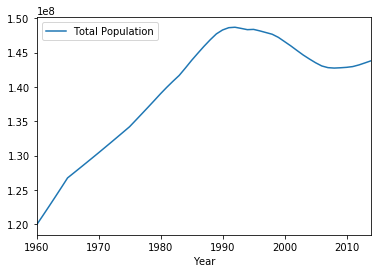

```python
russia.plot(x = 'Year', y = 'Total Population')
```

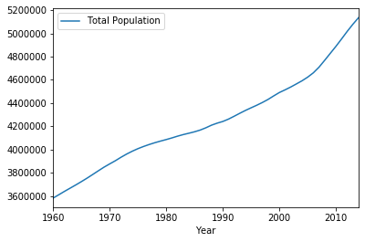

```python
norway.plot(x = 'Year', y = 'Total Population')
```

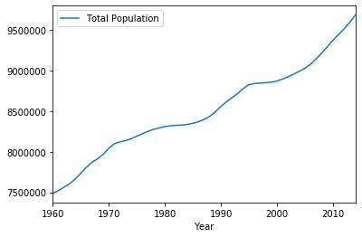

```python
sweden.plot(x = 'Year', y = 'Total Population')
```

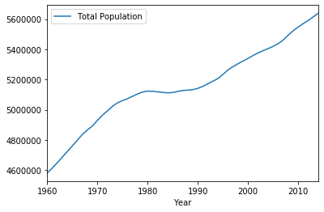

```python
denmark.plot(x = 'Year', y = 'Total Population')
```

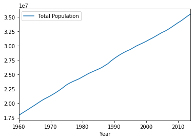

```python
canada.plot(x = 'Year', y = 'Total Population')
```

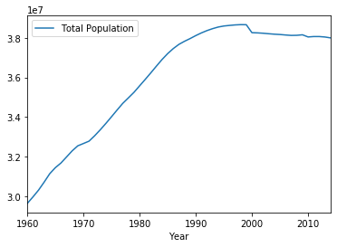

```python
poland.plot(x = 'Year', y = 'Total Population', xlim = 1960)
```

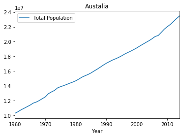

```python
australia.plot(x = 'Year', y = 'Total Population', title = 'Austalia')
```

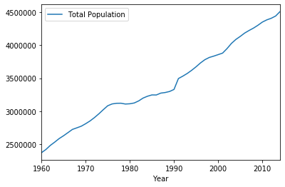

```python
new_zealand.plot(x = 'Year', y = 'Total Population')
```

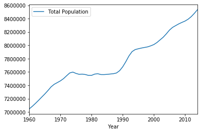

```python
austria.plot(x = 'Year', y = 'Total Population')
```

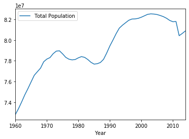

```python
germany.plot(x = 'Year', y = 'Total Population')
```

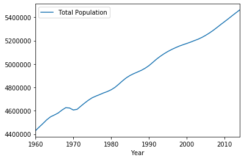

```python
finland.plot(x = 'Year', y = 'Total Population')
```

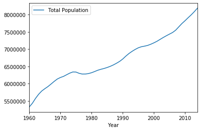

```python
switzerland.plot(x = 'Year', y = 'Total Population')
```

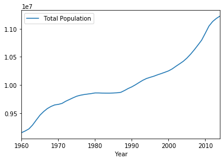

```python
belgium.plot(x = 'Year', y = 'Total Population')
```

## pandas scatter plots

```python
auto = pd.read_csv('auto-mpg.csv')
auto.head()
```

|  | mpg | cyl | displ | hp | weight | accel | yr | origin | name |
| --- | --- | --- | --- | --- | --- | --- | --- | --- | --- |
| 0 | 18.0 | 8 | 307.0 | 130 | 3504 | 12.0 | 70 | US | chevrolet chevelle malibu |
| 1 | 15.0 | 8 | 350.0 | 165 | 3693 | 11.5 | 70 | US | buick skylark 320 |
| 2 | 18.0 | 8 | 318.0 | 150 | 3436 | 11.0 | 70 | US | plymouth satellite |
| 3 | 16.0 | 8 | 304.0 | 150 | 3433 | 12.0 | 70 | US | amc rebel sst |
| 4 | 17.0 | 8 | 302.0 | 140 | 3449 | 10.5 | 70 | US | ford torino |

### Normalizing data

```python
sizes = auto['weight']
max_size = sizes.max()
weight = sizes/max_size
weight.head()
```

```
0    0.681712
1    0.718482
2    0.668482
3    0.667899
4    0.671012
Name: weight, dtype: float64
```

### Plotting a scatter

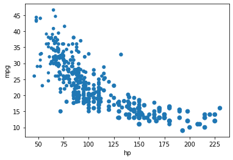

```python
auto.plot(kind='scatter', x='hp', y='mpg', s=weight*50)
```

## pandas box plots

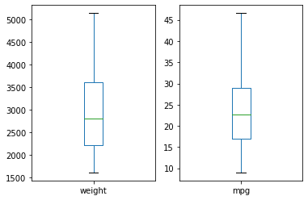

```python
cols = ['weight', 'mpg']
auto[cols].plot(kind='box', subplots = True)
plt.show()
```

## pandas hist, pdf and cdf

Pandas relies on the .hist() method to not only generate histograms, but also plots of **probability density functions (PDFs) and cumulative density functions (CDFs)**.

```python
tips = pd.read_csv('tips.csv')
tips.head()
```

|  | total_bill | tip | sex | smoker | day | time | size | fraction |
| --- | --- | --- | --- | --- | --- | --- | --- | --- |
| 0 | 16.99 | 1.01 | Female | No | Sun | Dinner | 2 | 0.059447 |
| 1 | 10.34 | 1.66 | Male | No | Sun | Dinner | 3 | 0.160542 |
| 2 | 21.01 | 3.50 | Male | No | Sun | Dinner | 3 | 0.166587 |
| 3 | 23.68 | 3.31 | Male | No | Sun | Dinner | 2 | 0.139780 |
| 4 | 24.59 | 3.61 | Female | No | Sun | Dinner | 4 | 0.146808 |

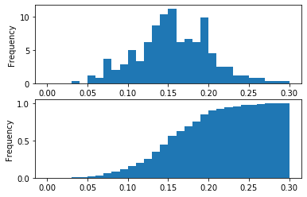

```python
# This formats the plots such that they appear on separate rows
fig, axes = plt.subplots(nrows=2, ncols=1)

#PDF - probability density functions
tips.fraction.plot(ax=axes[0], kind='hist', bins=30, density=True, range=(0,.3))

#CDF - cumulative density functions
tips.fraction.plot(ax=axes[1], kind='hist', bins=30, density=True, cumulative=True, range=(0,.3))
plt.show()
```

## Statistical exploratory data analysis

```python
iris.describe()
```

|  | sepal_length | sepal_width | petal_length | petal_width |
| --- | --- | --- | --- | --- |
| count | 150.000000 | 150.000000 | 150.000000 | 150.000000 |
| mean | 5.843333 | 3.054000 | 3.758667 | 1.198667 |
| std | 0.828066 | 0.433594 | 1.764420 | 0.763161 |
| min | 4.300000 | 2.000000 | 1.000000 | 0.100000 |
| 25% | 5.100000 | 2.800000 | 1.600000 | 0.300000 |
| 50% | 5.800000 | 3.000000 | 4.350000 | 1.300000 |
| 75% | 6.400000 | 3.300000 | 5.100000 | 1.800000 |
| max | 7.900000 | 4.400000 | 6.900000 | 2.500000 |

### Counts

```python
iris['sepal_length'].count() #Applied to Series
```

```
150
```

```python
iris['sepal_width'].count() #Applied to Series
```

```
150
```

```python
iris[['sepal_length', 'sepal_width']].count() #Applied to DataFrame
```

```
sepal_length    150
sepal_width     150
dtype: int64
```

```python
type(iris[['sepal_length', 'sepal_width']].count()) #returns Series
```

```
pandas.core.series.Series
```

### Averages

```python
iris['sepal_length'].mean() #Applied to Series
```

```
5.843333333333335
```

```python
iris.mean()  #Applied to entire DataFrame
```

```
sepal_length    5.843333
sepal_width     3.054000
petal_length    3.758667
petal_width     1.198667
dtype: float64
```

### Standart deviations

```python
iris.std()
```

```
sepal_length    0.828066
sepal_width     0.433594
petal_length    1.764420
petal_width     0.763161
dtype: float64
```

### Medians

```python
iris.median()
```

```
sepal_length    5.80
sepal_width     3.00
petal_length    4.35
petal_width     1.30
dtype: float64
```

### Medians & 0.5 quantiles

```python
# Median = 0.5 quantiles
q = 0.5
iris.quantile(q)
```

```
sepal_length    5.80
sepal_width     3.00
petal_length    4.35
petal_width     1.30
Name: 0.5, dtype: float64
```

```python
q75 = 0.75
iris.quantile(q75)
```

```
sepal_length    6.4
sepal_width     3.3
petal_length    5.1
petal_width     1.8
Name: 0.75, dtype: float64
```

```python
q25 = 0.25
iris.quantile(q25)
```

```
sepal_length    5.1
sepal_width     2.8
petal_length    1.6
petal_width     0.3
Name: 0.25, dtype: float64
```

```python
iris.quantile() #default = 0.5 - median
```

```
sepal_length    5.80
sepal_width     3.00
petal_length    4.35
petal_width     1.30
Name: 0.5, dtype: float64
```

```python
type(iris.quantile())
```

```
pandas.core.series.Series
```

### Inter-quartile range (IQR)

```python
q_both = [0.25, 0.75]
iris.quantile(q_both)
```

|  | sepal_length | sepal_width | petal_length | petal_width |
| --- | --- | --- | --- | --- |
| 0.25 | 5.1 | 2.8 | 1.6 | 0.3 |
| 0.75 | 6.4 | 3.3 | 5.1 | 1.8 |

```python
type(iris.quantile(q_both))
```

```
pandas.core.frame.DataFrame
```

### Ranges

```python
iris.min()
```

```
sepal_length            4.3
sepal_width               2
petal_length              1
petal_width             0.1
species         Iris-setosa
dtype: object
```

```python
iris.max()
```

```
sepal_length               7.9
sepal_width                4.4
petal_length               6.9
petal_width                2.5
species         Iris-virginica
dtype: object
```

### Box plots

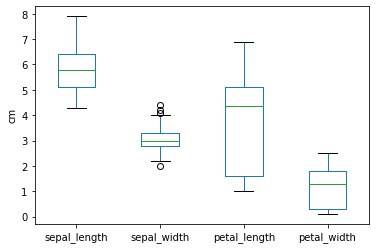

```python
iris.plot(kind='box')
plt.ylabel('cm')
plt.show()
```

## Bachelor's degrees awarded to women

```python
degree = pd.read_csv('percent-bachelors-degrees-women-usa.csv')
degree.head()
```

|  | Year | Agriculture | Architecture | Art and Performance | Biology | Business | Communications and Journalism | Computer Science | Education | Engineering | English | Foreign Languages | Health Professions | Math and Statistics | Physical Sciences | Psychology | Public Administration | Social Sciences and History |
| --- | --- | --- | --- | --- | --- | --- | --- | --- | --- | --- | --- | --- | --- | --- | --- | --- | --- | --- |
| 0 | 1970 | 4.229798 | 11.921005 | 59.7 | 29.088363 | 9.064439 | 35.3 | 13.6 | 74.535328 | 0.8 | 65.570923 | 73.8 | 77.1 | 38.0 | 13.8 | 44.4 | 68.4 | 36.8 |
| 1 | 1971 | 5.452797 | 12.003106 | 59.9 | 29.394403 | 9.503187 | 35.5 | 13.6 | 74.149204 | 1.0 | 64.556485 | 73.9 | 75.5 | 39.0 | 14.9 | 46.2 | 65.5 | 36.2 |
| 2 | 1972 | 7.420710 | 13.214594 | 60.4 | 29.810221 | 10.558962 | 36.6 | 14.9 | 73.554520 | 1.2 | 63.664263 | 74.6 | 76.9 | 40.2 | 14.8 | 47.6 | 62.6 | 36.1 |
| 3 | 1973 | 9.653602 | 14.791613 | 60.2 | 31.147915 | 12.804602 | 38.4 | 16.4 | 73.501814 | 1.6 | 62.941502 | 74.9 | 77.4 | 40.9 | 16.5 | 50.4 | 64.3 | 36.4 |
| 4 | 1974 | 14.074623 | 17.444688 | 61.9 | 32.996183 | 16.204850 | 40.5 | 18.9 | 73.336811 | 2.2 | 62.413412 | 75.3 | 77.9 | 41.8 | 18.2 | 52.6 | 66.1 | 37.3 |

```python
degree['Engineering'].min()
```

```
0.8
```

```python
degree['Engineering'].max()
```

```
19.0
```

### Mean across all columns per row

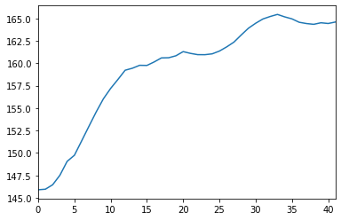

```python
# use the .mean() method with the keyword argument axis='columns'. This computes the mean across all columns per row.
mean = degree.mean(axis = 'columns')
mean.plot()
plt.show()
```

## Median vs mean

```python
titanic = pd.read_csv('titanic.csv', delimiter = ',')
titanic.head(2)
```

|  | pclass | survived | name | sex | age | sibsp | parch | ticket | fare | cabin | embarked | boat | body | home.dest |
| --- | --- | --- | --- | --- | --- | --- | --- | --- | --- | --- | --- | --- | --- | --- |
| 0 | 1 | 1 | Allen, Miss. Elisabeth Walton | female | 29.00 | 0 | 0 | 24160 | 211.3375 | B5 | S | 2 | NaN | St Louis, MO |
| 1 | 1 | 1 | Allison, Master. Hudson Trevor | male | 0.92 | 1 | 2 | 113781 | 151.5500 | C22 C26 | S | 11 | NaN | Montreal, PQ / Chesterville, ON |

```python
titanic.shape
```

```
(1309, 14)
```

```python
titanic.columns
```

```
Index(['pclass', 'survived', 'name', 'sex', 'age', 'sibsp', 'parch', 'ticket',
       'fare', 'cabin', 'embarked', 'boat', 'body', 'home.dest'],
      dtype='object')
```

```python
titanic.describe()
```

|  | pclass | survived | age | sibsp | parch | fare | body |
| --- | --- | --- | --- | --- | --- | --- | --- |
| count | 1309.000000 | 1309.000000 | 1046.000000 | 1309.000000 | 1309.000000 | 1308.000000 | 121.000000 |
| mean | 2.294882 | 0.381971 | 29.881138 | 0.498854 | 0.385027 | 33.295479 | 160.809917 |
| std | 0.837836 | 0.486055 | 14.413493 | 1.041658 | 0.865560 | 51.758668 | 97.696922 |
| min | 1.000000 | 0.000000 | 0.170000 | 0.000000 | 0.000000 | 0.000000 | 1.000000 |
| 25% | 2.000000 | 0.000000 | 21.000000 | 0.000000 | 0.000000 | 7.895800 | 72.000000 |
| 50% | 3.000000 | 0.000000 | 28.000000 | 0.000000 | 0.000000 | 14.454200 | 155.000000 |
| 75% | 3.000000 | 1.000000 | 39.000000 | 1.000000 | 0.000000 | 31.275000 | 256.000000 |
| max | 3.000000 | 1.000000 | 80.000000 | 8.000000 | 9.000000 | 512.329200 | 328.000000 |

```python
titanic.fare.describe()
```

```
count    1308.000000
mean       33.295479
std        51.758668
min         0.000000
25%         7.895800
50%        14.454200
75%        31.275000
max       512.329200
Name: fare, dtype: float64
```

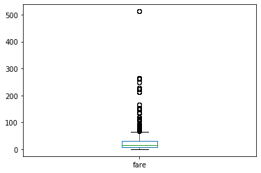

```python
titanic.fare.plot(kind = 'box')
```

## Quantiles

```python
life = pd.read_csv('life_expectancy_at_birth.csv')
life.head()
```

|  | Unnamed: 0 | Life expectancy | 1800 | 1801 | 1802 | 1803 | 1804 | 1805 | 1806 | 1807 | ... | 2007 | 2008 | 2009 | 2010 | 2011 | 2012 | 2013 | 2014 | 2015 | 2016 |
| --- | --- | --- | --- | --- | --- | --- | --- | --- | --- | --- | --- | --- | --- | --- | --- | --- | --- | --- | --- | --- | --- |
| 0 | 0 | Abkhazia | NaN | NaN | NaN | NaN | NaN | NaN | NaN | NaN | ... | NaN | NaN | NaN | NaN | NaN | NaN | NaN | NaN | NaN | NaN |
| 1 | 1 | Afghanistan | 28.21 | 28.20 | 28.19 | 28.18 | 28.17 | 28.16 | 28.15 | 28.14 | ... | 52.4 | 52.8 | 53.3 | 53.6 | 54.0 | 54.4 | 54.8 | 54.9 | 53.8 | 52.72 |
| 2 | 2 | Akrotiri and Dhekelia | NaN | NaN | NaN | NaN | NaN | NaN | NaN | NaN | ... | NaN | NaN | NaN | NaN | NaN | NaN | NaN | NaN | NaN | NaN |
| 3 | 3 | Albania | 35.40 | 35.40 | 35.40 | 35.40 | 35.40 | 35.40 | 35.40 | 35.40 | ... | 76.6 | 76.8 | 77.0 | 77.2 | 77.4 | 77.5 | 77.7 | 77.9 | 78.0 | 78.10 |
| 4 | 4 | Algeria | 28.82 | 28.82 | 28.82 | 28.82 | 28.82 | 28.82 | 28.82 | 28.82 | ... | 75.3 | 75.5 | 75.7 | 76.0 | 76.1 | 76.2 | 76.3 | 76.3 | 76.4 | 76.50 |

5 rows × 219 columns

```python
life['2015'].count()
```

```
208
```

```python
life.quantile([0.05, 0.95])
```

|  | Unnamed: 0 | 1800 | 1801 | 1802 | 1803 | 1804 | 1805 | 1806 | 1807 | 1808 | ... | 2007 | 2008 | 2009 | 2010 | 2011 | 2012 | 2013 | 2014 | 2015 | 2016 |
| --- | --- | --- | --- | --- | --- | --- | --- | --- | --- | --- | --- | --- | --- | --- | --- | --- | --- | --- | --- | --- | --- |
| 0.05 | 12.95 | 25.40 | 25.30 | 25.20 | 25.2 | 25.2 | 25.40 | 25.40 | 25.40 | 25.3 | ... | 53.07 | 53.60 | 54.235 | 54.935 | 55.97 | 56.335 | 56.705 | 56.87 | 57.855 | 59.2555 |
| 0.95 | 246.05 | 37.92 | 37.35 | 38.37 | 38.0 | 38.3 | 38.37 | 38.37 | 38.37 | 38.0 | ... | 80.73 | 80.93 | 81.200 | 81.365 | 81.60 | 81.665 | 81.830 | 82.00 | 82.100 | 82.1650 |

2 rows × 218 columns

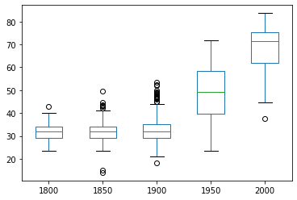

```python
years = ['1800', '1850', '1900', '1950', '2000']
life[years].plot(kind = 'box')
```

## Standard deviation of life expectancy

```python
life['1800'].std()
```

```
3.763584605080904
```

```python
life['1900'].std()
```

```
6.336988677401311
```

```python
life['2000'].std()
```

```
9.586078973420372
```

## Separating populations

### Describe species column

```python
iris.head()
```

|  | sepal_length | sepal_width | petal_length | petal_width | species |
| --- | --- | --- | --- | --- | --- |
| 0 | 5.1 | 3.5 | 1.4 | 0.2 | Iris-setosa |
| 1 | 4.9 | 3.0 | 1.4 | 0.2 | Iris-setosa |
| 2 | 4.7 | 3.2 | 1.3 | 0.2 | Iris-setosa |
| 3 | 4.6 | 3.1 | 1.5 | 0.2 | Iris-setosa |
| 4 | 5.0 | 3.6 | 1.4 | 0.2 | Iris-setosa |

```python
iris['species'].describe()
```

```
count                 150
unique                  3
top       Iris-versicolor
freq                   50
Name: species, dtype: object
```

### Unique & factors

```python
iris['species'].unique()
```

```
array(['Iris-setosa', 'Iris-versicolor', 'Iris-virginica'], dtype=object)
```

### Filtering by species

```python
indices = iris['species'] == 'Iris-setosa'
setosa = iris.loc[indices, :] #extract new DataFrame
setosa.head()
```

|  | sepal_length | sepal_width | petal_length | petal_width | species |
| --- | --- | --- | --- | --- | --- |
| 0 | 5.1 | 3.5 | 1.4 | 0.2 | Iris-setosa |
| 1 | 4.9 | 3.0 | 1.4 | 0.2 | Iris-setosa |
| 2 | 4.7 | 3.2 | 1.3 | 0.2 | Iris-setosa |
| 3 | 4.6 | 3.1 | 1.5 | 0.2 | Iris-setosa |
| 4 | 5.0 | 3.6 | 1.4 | 0.2 | Iris-setosa |

```python
indices = iris['species'] == 'Iris-versicolor'
versicolor = iris.loc[indices, :]
versicolor.head()
```

|  | sepal_length | sepal_width | petal_length | petal_width | species |
| --- | --- | --- | --- | --- | --- |
| 50 | 7.0 | 3.2 | 4.7 | 1.4 | Iris-versicolor |
| 51 | 6.4 | 3.2 | 4.5 | 1.5 | Iris-versicolor |
| 52 | 6.9 | 3.1 | 4.9 | 1.5 | Iris-versicolor |
| 53 | 5.5 | 2.3 | 4.0 | 1.3 | Iris-versicolor |
| 54 | 6.5 | 2.8 | 4.6 | 1.5 | Iris-versicolor |

```python
indices = iris['species'] == 'Iris-virginica'
virginica = iris.loc[indices, :]
virginica.head()
```

|  | sepal_length | sepal_width | petal_length | petal_width | species |
| --- | --- | --- | --- | --- | --- |
| 100 | 6.3 | 3.3 | 6.0 | 2.5 | Iris-virginica |
| 101 | 5.8 | 2.7 | 5.1 | 1.9 | Iris-virginica |
| 102 | 7.1 | 3.0 | 5.9 | 2.1 | Iris-virginica |
| 103 | 6.3 | 2.9 | 5.6 | 1.8 | Iris-virginica |
| 104 | 6.5 | 3.0 | 5.8 | 2.2 | Iris-virginica |

### Checking species

```python
setosa['species'].unique()
```

```
array(['Iris-setosa'], dtype=object)
```

```python
virginica['species'].unique()
```

```
array(['Iris-virginica'], dtype=object)
```

```python
versicolor['species'].unique()
```

```
array(['Iris-versicolor'], dtype=object)
```

```python
#deleting a column
del setosa['species'], virginica['species'], versicolor['species']
```

```python
setosa.head(2)
```

|  | sepal_length | sepal_width | petal_length | petal_width |
| --- | --- | --- | --- | --- |
| 0 | 5.1 | 3.5 | 1.4 | 0.2 |
| 1 | 4.9 | 3.0 | 1.4 | 0.2 |

```python
virginica.head(2)
```

|  | sepal_length | sepal_width | petal_length | petal_width |
| --- | --- | --- | --- | --- |
| 100 | 6.3 | 3.3 | 6.0 | 2.5 |
| 101 | 5.8 | 2.7 | 5.1 | 1.9 |

```python
versicolor.head(2)
```

|  | sepal_length | sepal_width | petal_length | petal_width |
| --- | --- | --- | --- | --- |
| 50 | 7.0 | 3.2 | 4.7 | 1.4 |
| 51 | 6.4 | 3.2 | 4.5 | 1.5 |

### Visual EDA

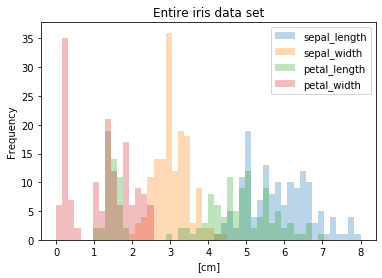

```python
iris.plot(kind='hist', bins=50, range=(0,8), alpha=0.3)
plt.title('Entire iris data set')
plt.xlabel('[cm]')
plt.show()
```

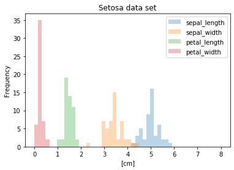

```python
setosa.plot(kind='hist', bins=50, range=(0,8), alpha=0.3)
plt.title('Setosa data set')
plt.xlabel('[cm]')
plt.show()
```

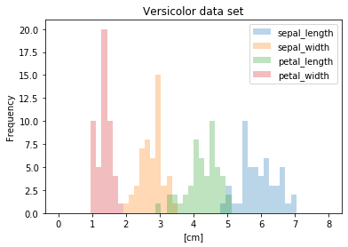

```python
versicolor.plot(kind='hist', bins=50, range=(0,8), alpha=0.3)
plt.title('Versicolor data set')
plt.xlabel('[cm]')
plt.show()
```

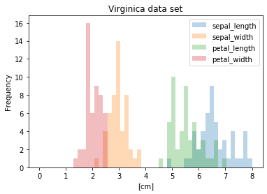

```python
virginica.plot(kind='hist', bins=50, range=(0,8), alpha=0.3)
plt.title('Virginica data set')
plt.xlabel('[cm]')
plt.show()
```

### Statistical EDA: describe()

```python
describe_all = iris.describe()
describe_all
```

|  | sepal_length | sepal_width | petal_length | petal_width |
| --- | --- | --- | --- | --- |
| count | 150.000000 | 150.000000 | 150.000000 | 150.000000 |
| mean | 5.843333 | 3.054000 | 3.758667 | 1.198667 |
| std | 0.828066 | 0.433594 | 1.764420 | 0.763161 |
| min | 4.300000 | 2.000000 | 1.000000 | 0.100000 |
| 25% | 5.100000 | 2.800000 | 1.600000 | 0.300000 |
| 50% | 5.800000 | 3.000000 | 4.350000 | 1.300000 |
| 75% | 6.400000 | 3.300000 | 5.100000 | 1.800000 |
| max | 7.900000 | 4.400000 | 6.900000 | 2.500000 |

```python
describe_setosa = setosa.describe()
describe_versicolor = versicolor.describe()
describe_virginica = virginica.describe()
```

### Computing errors

```python
errors_setosa = 100 * np.abs(describe_setosa - describe_all)
errors_setosa = errors_setosa/describe_setosa
errors_setosa
```

|  | sepal_length | sepal_width | petal_length | petal_width |
| --- | --- | --- | --- | --- |
| count | 200.000000 | 200.000000 | 200.000000 | 200.000000 |
| mean | 16.726595 | 10.649503 | 156.739526 | 391.256831 |
| std | 134.919250 | 13.796994 | 916.891608 | 611.840574 |
| min | 0.000000 | 13.043478 | 0.000000 | 0.000000 |
| 25% | 6.250000 | 10.400000 | 14.285714 | 50.000000 |
| 50% | 16.000000 | 11.764706 | 190.000000 | 550.000000 |
| 75% | 23.076923 | 10.204082 | 223.809524 | 500.000000 |
| max | 36.206897 | 0.000000 | 263.157895 | 316.666667 |

```python
errors_versicolor = 100 * np.abs(describe_versicolor - describe_all)
errors_versicolor = errors_versicolor/describe_versicolor
errors_versicolor
```

|  | sepal_length | sepal_width | petal_length | petal_width |
| --- | --- | --- | --- | --- |
| count | 200.000000 | 200.000000 | 200.000000 | 200.000000 |
| mean | 1.561096 | 10.252708 | 11.768388 | 9.602815 |
| std | 60.424722 | 38.176108 | 275.479720 | 285.916763 |
| min | 12.244898 | 0.000000 | 66.666667 | 90.000000 |
| 25% | 8.928571 | 10.891089 | 60.000000 | 75.000000 |
| 50% | 1.694915 | 7.142857 | 0.000000 | 0.000000 |
| 75% | 1.587302 | 10.000000 | 10.869565 | 20.000000 |
| max | 12.857143 | 29.411765 | 35.294118 | 38.888889 |

```python
errors_virginica = 100 * np.abs(describe_virginica - describe_all)
errors_virginica = errors_virginica/describe_virginica
errors_virginica
```

|  | sepal_length | sepal_width | petal_length | petal_width |
| --- | --- | --- | --- | --- |
| count | 200.000000 | 200.000000 | 200.000000 | 200.000000 |
| mean | 11.303380 | 2.689980 | 32.300672 | 40.835801 |
| std | 30.223731 | 34.449250 | 219.702370 | 177.866589 |
| min | 12.244898 | 9.090909 | 77.777778 | 92.857143 |
| 25% | 18.072289 | 0.000000 | 68.627451 | 83.333333 |
| 50% | 10.769231 | 0.000000 | 21.621622 | 35.000000 |
| 75% | 7.246377 | 3.937008 | 13.191489 | 21.739130 |
| max | 0.000000 | 15.789474 | 0.000000 | 0.000000 |

```python
mpg = pd.read_csv('mpg.csv')
del mpg['Unnamed: 0']
mpg.head()
```

|  | accel | cyl | displ | hp | mpg | name | origin | weight | yr |
| --- | --- | --- | --- | --- | --- | --- | --- | --- | --- |
| 0 | 12.0 | 8 | 307.0 | 130 | 18.0 | chevrolet chevelle malibu | US | 3504 | 70 |
| 1 | 11.5 | 8 | 350.0 | 165 | 15.0 | buick skylark 320 | US | 3693 | 70 |
| 2 | 11.0 | 8 | 318.0 | 150 | 18.0 | plymouth satellite | US | 3436 | 70 |
| 3 | 12.0 | 8 | 304.0 | 150 | 16.0 | amc rebel sst | US | 3433 | 70 |
| 4 | 10.5 | 8 | 302.0 | 140 | 17.0 | ford torino | US | 3449 | 70 |

```python
mpg.shape
```

```
(392, 9)
```

# **Time series in pandas**

# **Case Study - Sunlight in Austin**